# reproducible_figures_assignment

P Number:8645

2023-11-16

to enable knitting of the document, i first must install and load the tinytex package.

[output not shown]

[output not shown]

**Question 1: Data visualisation for Science Communication**

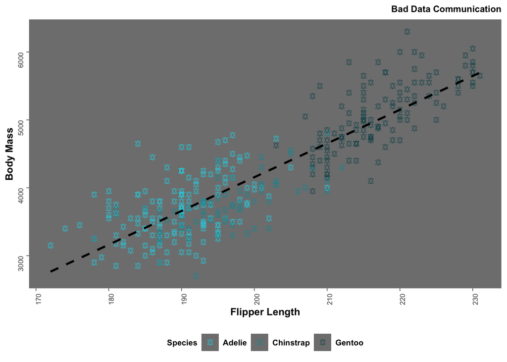

**1b:** Presenting visually clear, informative figures is key to any successful scientific communication. Readers often examining figures first (Jambor *et al,* 2021), therefore making figures that are accessible to a broad audience is cardinal. Despite their importance, most scientists are not formally trained in graph design (Jambor *et al,* 2021), and under publishing pressure (Baker *et al,* 2016), graphs that poorly communicate the results are often created.

The graph above displays some common misleading features. Firstly, the lack of clear title, in addition to being placed counterintuitively on the right-hand side makes it hard to initially see what the graph is presenting. Furthermore, the orientation of the axis titles, and the lack of units, reduces understandability. Visually, the shades of blue are too similar, making it hard to distinguish between shades and further makes the figure inaccessible to colour-blind readers. The reduced contrast with the dark background, in addition to no grid lines, creates a graph that is hard to place to any quantitative meaning. In addition, the shape and transparency of the points makes it harder to identify their precise location. The dashed line of best fit could mislead viewers regarding the relationship between flipper length and body mass, rather than distinguishing between groups of penguins. Finally, no differentiation between the legend title and the labels could also mislead interpretations of the figure.

As open access in scientific work becomes more ubiquitous, with increasing data and code sharing (McKiernan *et al,* 2016), it is ever more key to be clear in our communications and produce visually informative figures that accurately communicate the data.

**References**

1. Baker, M. 1,500 scientists lift the lid on reproducibility. *Nature* **533**, 452–454 (2016). https://doi.org/10.1038/533452a
2. McKiernan, E. C. et al. (2016) How open science helps researchers succeed. *eLife*. [Online] 5.
3. Jambor, H. et al. (2021) Creating clear and informative image-based figures for scientific publications. *PLoS biology*. [Online] 19 (3), e3001161–e3001161.

**Question 2: Data Pipeline**

**Introduction**

Working with the Palmer Penguins data set, i will investigate and test whether the average mass differs significantly between penguin sex, across all 3 species of penguin.

1. loading in the data

```r
#saves the data into a data file within my project
write.csv(penguins_raw, "data/penguins_raw.csv")

#reading in the data from the file
penguins_raw <- read.csv("data/penguins_raw.csv")

#checking the data
penguins_raw
```

[output not shown]

2. cleaning the data, using pipes.

The column names of the data are not useful for coding, therefore it is important to rename them. in addition, the species names are saved in long form, it would be useful to have this in short form. Removing NA values, where data is missing, is also beneficial to our analysis. B

By first defining these cleaning functions, it enables the function to be used again without retyping out the data pipe. I have used the cleaning functions presented in the lesson.

the functions are saved within an r script as part of the project

```r
source("functions/cleaning_functions.R")

#cleaning the data
penguins_clean <- penguins_raw %>%
  clean_column_names() %>%
  shorten_species() %>%
  remove_empty_columns_rows() %>%
  remove_NA()

head(penguins_clean)
```

[output not shown]

**Hypothesis**

I was interested to see whether there is a significant difference in body mass between male and female penguins. Perhaps female penguins are larger, if this would enable more warmth to be retained when incubating the eggs and provisioning the eggs in the first place, whilst larger males may be a sign of superior fishing quality or offer better protection for their offspring. to explore this, a box plot that shows the range of the data, whilst also representing the individual points would be beneficial before undergoing further data analysis.

to make sure the graph is reproducible, as there is a function that involves randomization of x axis values for the points, set.seed is incorporated.

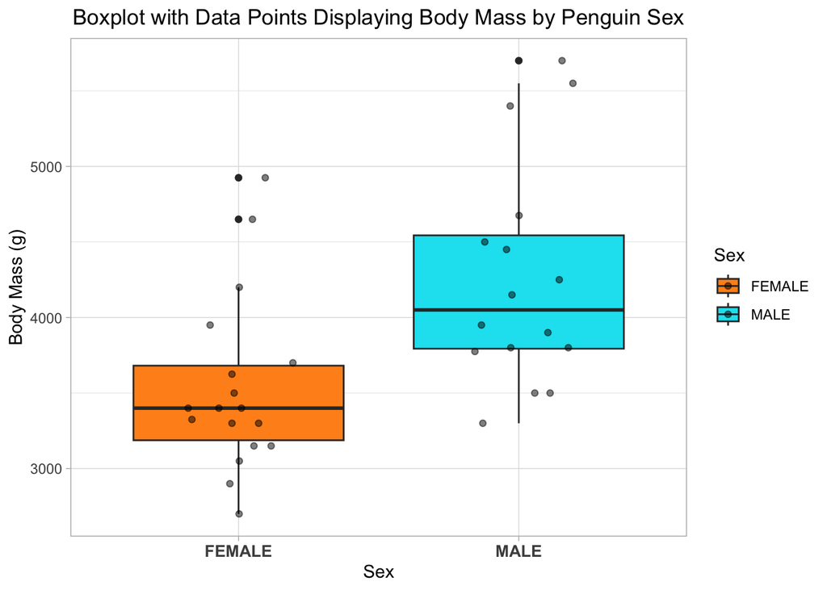

```r
# Set a seed for reproducibility
set.seed(123)

#adding the data
mass_sex_boxplot <- ggplot(penguins_clean, aes(x = sex, y = body_mass_g, fill = sex)) +
  geom_boxplot() +
  geom_jitter(position = position_jitter(width = 0.2, height = 0), alpha = 0.5) +
  theme_light() +


  #changing colours
  scale_fill_manual(values = c("#FF921D", "#07E2F0")) +
  scale_color_manual(values = c("#FF921D", "#07E2F0")) +
  labs(title = "Boxplot with Data Points Displaying Body Mass by Penguin Sex",
       x = "Sex",
       y = "Body Mass (g)",
       fill = "Sex") +

#centering the title
theme(plot.title = element_text(hjust = 0.5), axis.text.x = element_text(face = "bold", size = 10))

#viewing the figure
mass_sex_boxplot
```

```r
ggsave("mass_sex_boxplot.pdf", plot = mass_sex_boxplot, device = "pdf", width = 8, height = 6, units = "in")
```

as a result of the exploratory plot, the hypotheses can be formally stated as:

**Ho**: there is no statistically significant difference between the body mass of male and female penguins

**Ha**: male penguins have a significantly greater body mass than female penguins

**Statistical Methods**

before conducting statistical analysis, it would be useful to create subsets of our data for the body mass of male and female penguins

```r
sex_bodymass_data <- penguins_clean %>%
  select(body_mass_g, sex)

#creating individual data tables for body mass of male and female penguins
female_data <- subset(penguins, sex == "female", select = body_mass_g)
male_data <- subset(penguins, sex == "male", select = body_mass_g)

#creating a table of the mean body mass for male and female penguins
mean_table <- sex_bodymass_data %>%
  group_by(sex) %>%
  summarise(mean_body_mass = mean(body_mass_g, na.rm = TRUE))

#viewing the result
mean_table
```

```
## # A tibble: 2 × 2
##   sex    mean_body_mass
##   <chr>           <dbl>
## 1 FEMALE          3535.
## 2 MALE            4262.
```

```r
t_test_result <- t.test(female_data$body_mass_g, male_data$body_mass_g)

#viewing the result
print(t_test_result)
```

```
##
##  Welch Two Sample t-test
##
## data:  female_data$body_mass_g and male_data$body_mass_g
## t = -8.5545, df = 323.9, p-value = 4.794e-16
## alternative hypothesis: true difference in means is not equal to 0
## 95 percent confidence interval:
##  -840.5783 -526.2453
## sample estimates:
## mean of x mean of y
##  3862.273  4545.685
```

**Results & Discussion**

with an extremely small P value, it would be appropriate to reject the null hyopothesis of equal masses between male and female penguins, therefore it is likely there is a significant difference in mass, determined by sex.

**results figure**

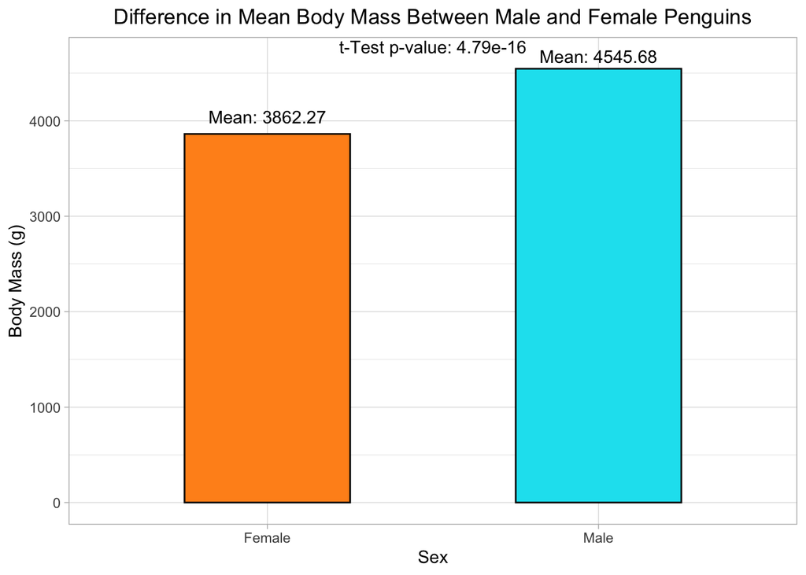

the figure displays the result of mass difference between penguins. this could be because fatter males are more popular for females, with mass perhaps being an indicator of fishing ability (Horvath, 2015). As a result, there would be selection for larger males, if they are preferred by females. despite the statistical significance, there is not a drastic difference in body mass, with large females being beneficial given this would enhance heat retention and be useful for incubation.